# Problem Set 3 - Part 1

# Voting in the United Nations General Assembly

Like legislators in the US Congress, the member states of the United Nations (UN) are politically divided on many issues such as trade, nuclear disarmament, and human rights. During the Cold War, countries in the UN General Assembly tended to split into two factions: one led by the capitalist United States and the other by the communist Soviet Union. In this exercise, we will analyze how states’ ideological positions, as captured by their votes on UN resolutions, have changed since the fall of communism.

This exercise is based on Michael A. Bailey, Anton Strezhnev, and Erik Voeten. “Estimating Dynamic State Preferences from United Nations Voting Data.” *Journal of Conflict Resolution*, August 2015.

The data is called `unvoting_adj.csv` and the variables are:

| Name | Description |
| --- | --- |
| `CountryName` | The name of the country |
| `idealpoint` | Its estimated ideal point |
| `Year` | The year for which the ideal point is estimated |
| `PctAgreeUS` | The percentage of votes that agree with the US on the same issue |
| `PctAgreeRUSSIA` | The percentage of votes that agree with Russia/the Soviet Union on the same issue |
| `distanceToRussia`* | Distance from Moscow to the capital of a given country in kilometers |

The `distanceToRussia` variable was added to the original data set only for the purposes of this problem set. The source for this variable is https://www.distance-between-countries.com/countries/distance_between_countries.php?from=Russia&language=English&dist_order=1

In the analysis that follows, we measure state preferences in two ways. Note that the data for 1964 are missing due to the absence of roll call data.

First, we can use the percentage of votes by each country that coincide with votes on the same issue cast by the two major Cold War powers: the United States and the Soviet Union. For example, if a country voted for ten resolutions in 1992, and if its vote matched the United States’s vote on exactly six of these resolutions, the variable `PctAgreeUS` in 1992 would equal 60 for this country.

Second, we can also measure state preferences in terms of numerical ideal points.  
These ideal points capture what international relations scholars have called countries’ *liberalism* on issues such as *political freedom, democratization, and financial liberalization*. The two measures are highly correlated, with larger (more liberal) ideal points corresponding to a higher percentage of votes that agree with the US.

## Question 1 (15 points)

We begin by examining how the distribution of state ideal points (liberalism) has changed since the end of communism.

- Plot the distribution of ideal points separately for 1980 (about 10 years before the fall of the Berlin Wall) and 2000 (about ten years after the fall of the Berlin Wall). Make two separate plots. (5 points)
- Add the median to each plot as a vertical red line. (2 points)

Answer the following questions in the text (8 points):

- How do the two distributions differ?
- Do you see any changes in the distribution after the fall of the Berlin Wall?
- What changes do you see? Pay attention to the degree of polarization and give a brief substantive interpretation of the results.
- Use the `quantile` function to quantify (support with numbers) the patterns you identified.

## Answer 1

```r
un <- read.csv("data/unvoting_adj.csv")
head(un)
```

|  | Year | CountryAbb | CountryName | idealpoint | PctAgreeUS | PctAgreeRUSSIA | distanceToRussia |
| --- | --- | --- | --- | --- | --- | --- | --- |
| 1 | 1946 | USA | United States of America | 1.713689 | 1 | 0.2142857 | 7813 |
| 2 | 1947 | USA | United States of America | 1.812884 | 1 | 0.2631579 | 7813 |
| 3 | 1948 | USA | United States of America | 1.936166 | 1 | 0.1274510 | 7813 |
| 4 | 1949 | USA | United States of America | 1.876619 | 1 | 0.1111111 | 7813 |
| 5 | 1950 | USA | United States of America | 1.810646 | 1 | 0.1730769 | 7813 |
| 6 | 1951 | USA | United States of America | 1.827585 | 1 | 0.1200000 | 7813 |

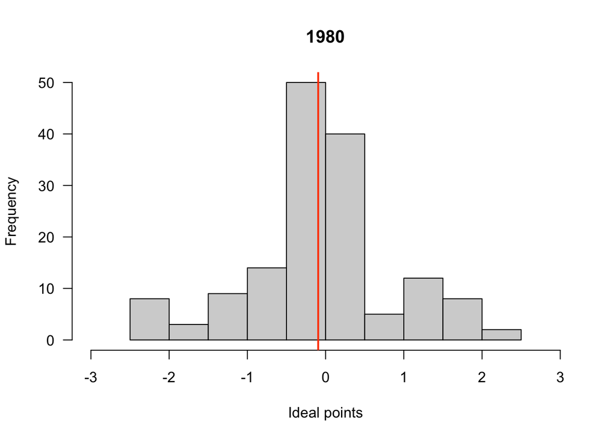

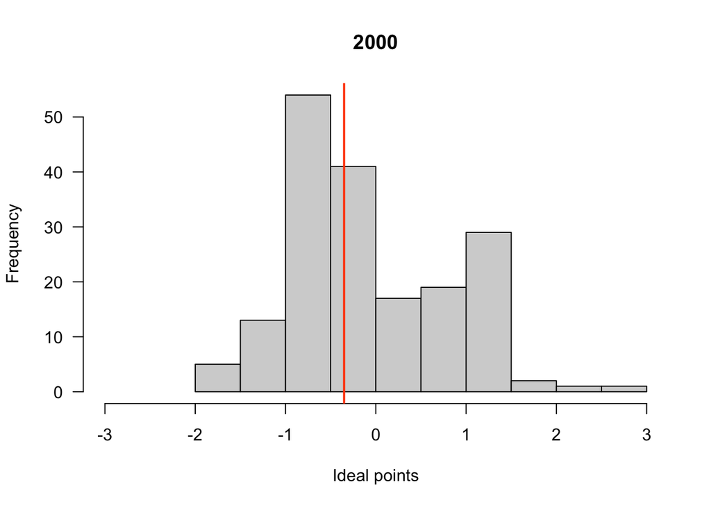

**Quantiles of ideal points in 1980**

```
##          0%         25%         50%         75%        100%
## -2.35749800 -0.34559800 -0.09465057  0.34365995  2.31760700
```

**Quantiles of ideal points in 2000**

```
##         0%        25%        50%        75%       100%
## -1.7018510 -0.7021018 -0.3514302  0.6200154  2.6105410
```

## Question 2 (20 points)

Next, examine how the number of countries voting with the US has changed over time.

- Plot the average percent agreement with US across all counties over time (meaning the average percent agreement with US by year). Use color `steelblue2` (5 points)
- For comparison, add the average percent agreement with Russia across all countries over time. Use color `orangered` (5 points)

Answer the following questions in the text:

- Does the US appear to be getting more or less isolated over time, as compared to Russia? (2 points)
- What are the countries that are consistently pro-US? List the top 5 countries. Hint*: you can calculate the mean agreement with US* per country*. Here the `sort()` function might be helpful. `sort(x,decreasing = TRUE)` will sort the values in the x vector in a decreasing order, starting from highest to lowest. (3 points)
- What are the most pro-Russian countries? List the top 5. Hint*: see hint above (3 points)
- Give a brief substantive interpretation of the results. (2 points)

## Answer 2

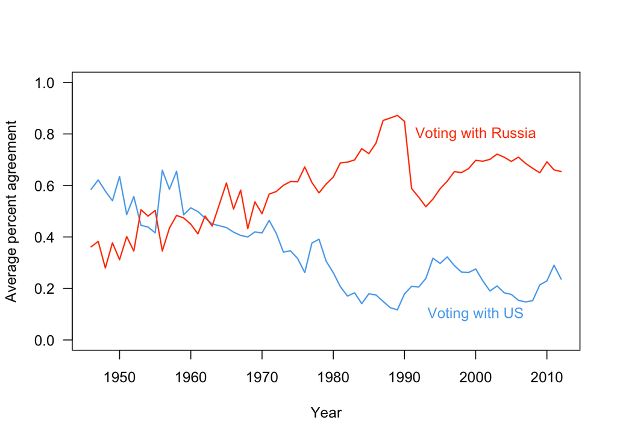

**Top 5 pro-US countries (excluding US) and their mean agreement with US**

```
##                          Palau                 United Kingdom
##                      0.7356335                      0.6521001
##                         Taiwan                         Israel
##                      0.6430106                      0.6399077
## Federated States of Micronesia
##                      0.5937617
```

**Top 5 pro-Russian countries (excluding Russia) and their mean agreement with Russia**

```
## German Democratic Republic             Czechoslovakia
##                  0.9888348                  0.9580425
##                    Belarus                    Ukraine
##                  0.9240236                  0.8871891
##                     Poland
##                  0.8669650
```

## Question 3 (20 points)

One problem of using the percentage of votes that agree with the US or Russia as a measure of state preferences is that the ideological positions, and consequently the voting patterns, of the two countries might have themselves changed over time. This makes it difficult to know which countries’ ideological positions have changed - those of Russia/US or of the other countries.

- Investigate this issue by plotting the evolution of the two countries’ *ideal points* over time. Use `steelblue2` for US and `orangered` for Russia. (10 points)
- Add the yearly *median* ideal point of all countries (including US and Russia). (6 points)
- How might the results of this analysis modify (or not) your interpretation of the previous analysis in question 2? What is the reason for Russia becoming more popular - because more countries increasingly agree with Russia, or because Russia has moved closer to the median after the fall of the Berlin Wall? (4 points)

## Answer 3

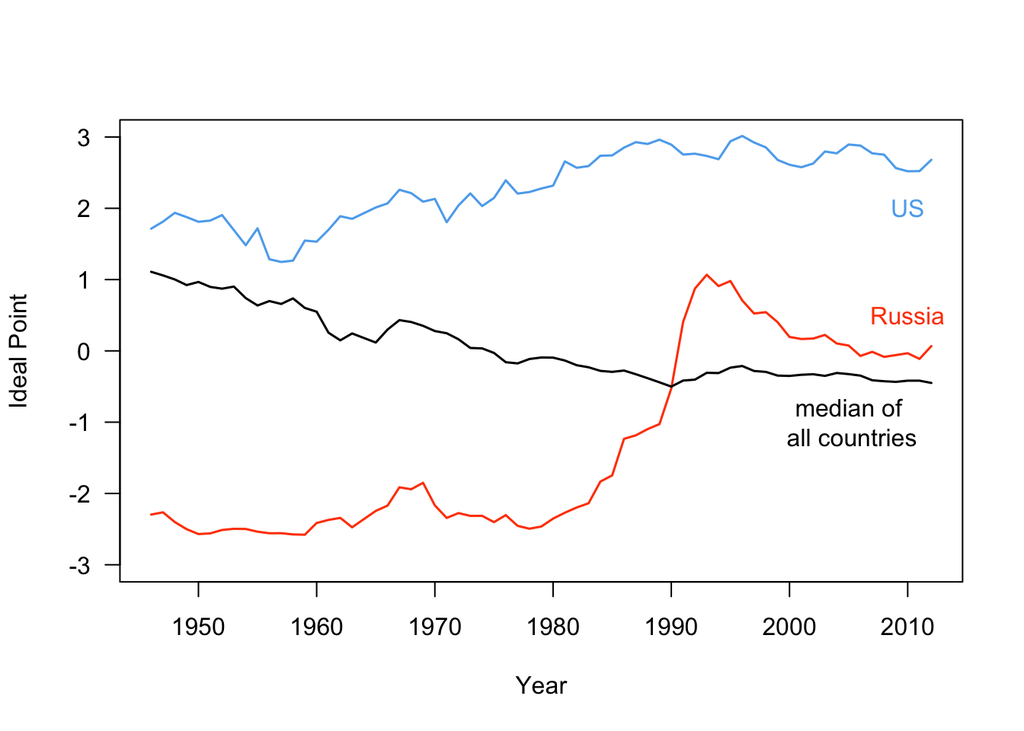

## Question 4 (25 points)

Let’s examine how countries that were formerly part of the Soviet Union differ in terms of their ideology and UN voting compared to countries that were not part of the Soviet Union. The former Soviet Union countries are: Estonia, Latvia, Lithuania, Belarus, Moldova, Ukraine, Armenia, Azerbaijan, Georgia, Kazakhstan, Kyrgyzstan, Turkmenistan, Tajikistan, Uzbekistan, and Russia.

- Create a binary variable called `post.soviet`, which takes the value 1 if a country was part of the former Soviet Union and 0 otherwise. Hint*: The `%in%` operator, which is used as `x %in% y`, may be helpful This operator returns a logical vector whose element is `TRUE` (`FALSE`) if the corresponding element of vector `x` is equal (not equal) to a value contained in vector `y`. (6 points)
  - For example let’s say you have a vector with food products in Spar and food items you want to buy. You can check which items in Spar you want to buy using the `%in%` operator the following way.

```r
## create objects with food items
Spar <- c("bread","pasta", "salt", "butter", "beer", "coca-cola","tomatoes", "pizza", "milk", "ham")
shopping_list <- c("coca-cola", "pizza", "butter", "chewing gum")

## check which items in Spar are contained in the shopping list
in_shopping_list <- Spar %in% shopping_list # for each item in the Spar object, R asks is this item in the shopping list or not and returns TRUE or FALSE.
in_shopping_list
```

```
##  [1] FALSE FALSE FALSE  TRUE FALSE  TRUE FALSE  TRUE FALSE FALSE
```

```r
## show the comparison along with the Sparlist
cbind(Spar, in_shopping_list)
```

```
##       Spar        in_shopping_list
##  [1,] "bread"     "FALSE"
##  [2,] "pasta"     "FALSE"
##  [3,] "salt"      "FALSE"
##  [4,] "butter"    "TRUE"
##  [5,] "beer"      "FALSE"
##  [6,] "coca-cola" "TRUE"
##  [7,] "tomatoes"  "FALSE"
##  [8,] "pizza"     "TRUE"
##  [9,] "milk"      "FALSE"
## [10,] "ham"       "FALSE"
```

- Lets say you want to create a binary variable which denotes whether you want to buy a product from Spar or not. You can do this the following way:

```r
## create a binary variable, which is equal to 1 if a food item from the supermarket is contained in the shopping list, 0 if not
want_to_buy <- ifelse(Spar %in% shopping_list, 1, 0)
want_to_buy
```

```
##  [1] 0 0 0 1 0 1 0 1 0 0
```

```r
## show the binary variable along with the supermarket list
cbind(Spar, want_to_buy)
```

```
##       Spar        want_to_buy
##  [1,] "bread"     "0"
##  [2,] "pasta"     "0"
##  [3,] "salt"      "0"
##  [4,] "butter"    "1"
##  [5,] "beer"      "0"
##  [6,] "coca-cola" "1"
##  [7,] "tomatoes"  "0"
##  [8,] "pizza"     "1"
##  [9,] "milk"      "0"
## [10,] "ham"       "0"
```

- Focus on the most recently available UN data from 2012 (3 points)
- Then, plot each Post-Soviet Union state’s ideal point (x-axis) against the percentage of its votes that agree with the United States (y-axis). (3 points) Whereby you
  - color Post-Soviet Union states in `orangered`, transparency level 0.5. Hint: you can adjust the transparency level of colors by passing the color to the `adjustcolor()` function. For example, `adjustcolor(col = "green", alpha.f = 0.5)` will give you a green color which is roughly speaking half transparent.
  - and insert a label “Post-Soviet States” in the same color.
- Add to the same plot also the other countries (non Post-Soviet Union countries) and color these in `steelblue2`, with transparency level 0.3. Insert a label “Other Countries”. (3 points)
- Compare the post Soviet Union states against the other countries in the text. Briefly comment on what you observe. Which of the post Soviet countries are non-liberal and which are highly liberal? Mention a few. Hint*: countries with larger values of the ideal positions are more liberal. It might be useful to use the `quantile()` function to find the most extreme non-liberal countries (the countries in the first few percentiles) and the most extreme liberal countries (the countries in the last few percentiles). (10 points)

## Answer 4

**For your information: percentage of post-soviet Union countries**

```
## [1] 0.04912281
```

### Plot

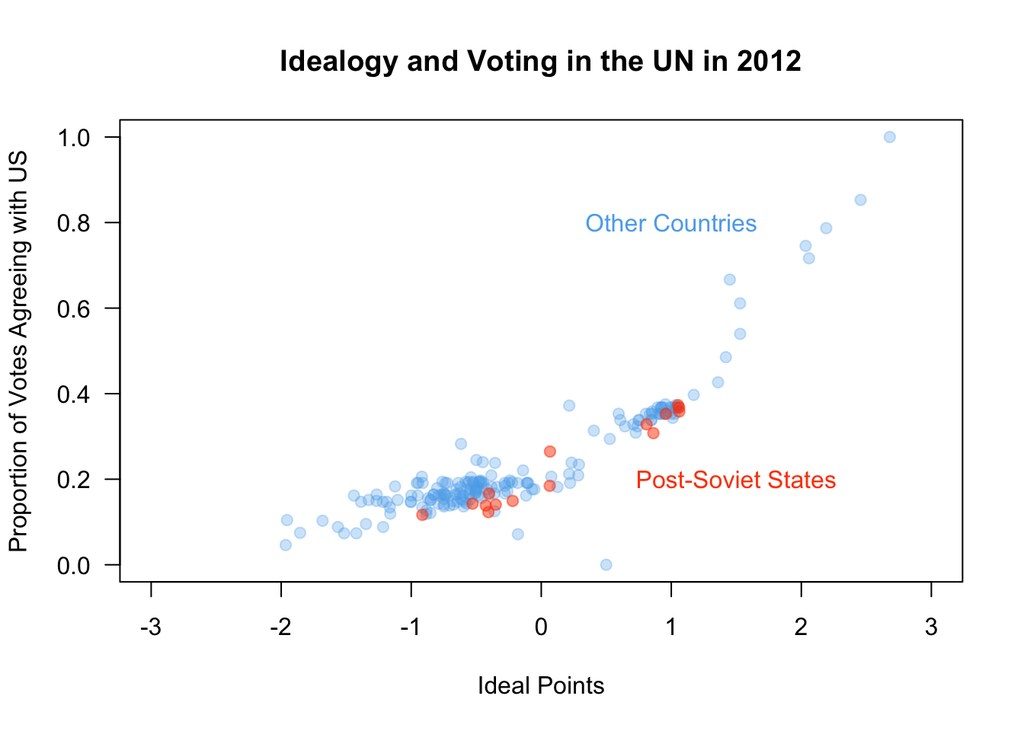

**10th percentile of the variable `idealpoint`**

```
##       10%
## -1.083951
```

**Countries with ideal positions in the first 10th percentile (non-liberal)**

```
##  [1] "Cuba"                "Nicaragua"           "Venezuela"
##  [4] "Ecuador"             "Bolivia"             "Zimbabwe"
##  [7] "Algeria"             "Sudan"               "Iran"
## [10] "Egypt"               "Syria"               "Lebanon"
## [13] "Saudi Arabia"        "Yemen Arab Republic" "Kuwait"
## [16] "Qatar"               "Oman"                "North Korea"
## [19] "Myanmar"             "Vietnam"
```

**90th percentile of the variable `idealpoint`**

```
##      90%
## 1.024346
```

**Countries with ideal positions above the 90th percentile (most liberal countries)**

```
##  [1] "United States of America"       "Canada"
##  [3] "United Kingdom"                 "Netherlands"
##  [5] "Belgium"                        "France"
##  [7] "Poland"                         "Hungary"
##  [9] "Czech Republic"                 "Slovakia"
## [11] "Romania"                        "Estonia"
## [13] "Latvia"                         "Lithuania"
## [15] "Israel"                         "Australia"
## [17] "Nauru"                          "Marshall Islands"
## [19] "Palau"                          "Federated States of Micronesia"
```

## Question 5 (20 points)

We have just seen that while some post-Soviet countries have retained non-liberal ideologies, other post-Soviet countries were much more liberal in 2012.

Let’s examine how the **median ideal points** of Soviet/post-Soviet countries and all other countries has varied over all the years in the data.

- Plot these median ideal points by year. (12 points)
- Indicate 1989, the year of the fall of the Berlin Wall, on the graph using a dashed vertical line. (3 points)
- Briefly comment on what you observe in the text. (5 points)

## Answer 5

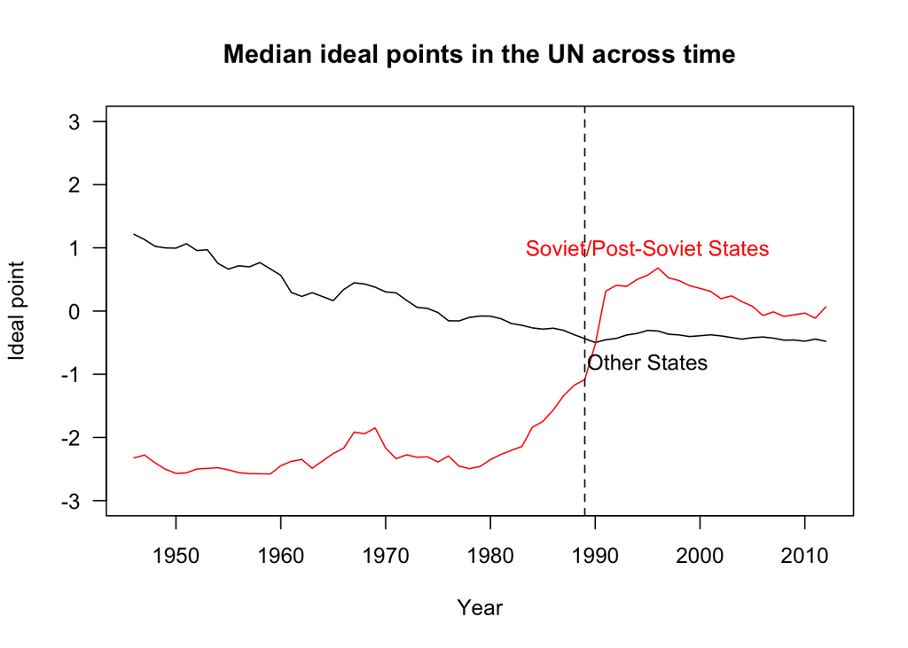

## Bonus Question 6 (25 points)

Imagine you work in the data science department of a think tank. Your boss is very happy with your previous graphs about voting patterns in the UN General Assembly. Upon looking at the graphs she thinks there might be another pattern in the data worthwhile exploring - voting in agreement with Russia and US might be driven not only by the ideology of countries, but also by their economic and political dependency from the two major Cold War powers. Looking into the data, you see that you do not have any variables which measure economic factors, but you have a variable, which captures the geographic closeness to Russia - the distance to Russia in kilometers. While not ideal, distance to Russia might be a rough proxy for the intensity of economic relations, as well as political influence of Russia. Explore whether political ideology and geographic closeness to Russia are related to the voting patterns in the UN by doing the following:

- First, check the correlation between these variables.
- Then, plot the average ideal points of countries against their average percentage agreement with Russia. Include distance to Russia as a size for the points - they should be proportional to the distance of the country to Russia. Make the figure a bit more informative by coloring post-soviet countries in red and the remaining ones in blue, make the points transparent to see overlaps. Then add country labels for several countries with high and low agreement with Russia. In particular add labels for `Russia`, `Belarus`, `Czechoslovakia`, `Hungary`, `Poland`, `Ukraine`, `United States of America`, `Austria`, `German Democratic Republic`, `Israel`.

To achieve this you can follow the below steps. Note that there are many ways to make the same plot and the below steps are only possible one way.

- (for 5 points): To plot the average ideal points (`idealpoint`) of countries against their average percentage agreement with Russia (`PctAgreeRUSSIA`).
  - First, transform the variable `CountryName` to a factor variable.
  - Then you need to calculate the average values of these variables by country and save these in separate objects. (Hopefully, this reminds you about `tapply`). Combine these average values into one object called `un_means`. (For this purpose you can use the `cbind()` function, which combines vectors by columns).
  - You might want to add the distance to Russia information to the `un_means` object. If you want to add a variable to your object, you need to transform it to a data format. To transform an object into a data format you can use the `as.data.frame()` function. (e.g. `un_means2 <- as.data.frame(un_means)` will transform `un_means` to a `data.frame` format and save it in a new object called `un_means2`). Adding the distance to Russia variable will be tricky - you need to create an object with distance to Russia by country (hint you can use `tapply` here too). Then you can use the `merge()` function to combine `un_means` and your distance to Russia. Do not hesitate to ask questions on Slack on this.
- Color post-soviet countries in `orangered`, color the remaining countries in `steelblue2` using for both colors transparency level 0.3. Add an informative legend. (2 points)
- Indicate the following countries on the plot using the country name abbreviation: `Russia`, `Belarus`, `Czechoslovakia`, `Hungary`, `Poland`, `Ukraine`, `United States of America`, `Austria`, `German Democratic Republic`, `Israel` (5 points)
- The size of the points should be proportional to the distance of this country to Russia (use the variable `distanceToRussia`) - bigger distance - bigger points. Hint: You can not use the actual distance to Russia as a size of your points, as this will make the points enormous. The size of the points should range somewhere between 0.2 until about 10 to be visible on the graph. Play around to get an informative graph, the points do not have to be the exact same size as in the example below. Be careful when you use distance to Russia as a size for your points - make sure that the *order* of countries in your ideology country means, agreement with Russia country means and country distances to Russia variables is the same. (10 points)
- Discuss your findings from the correlations and the graph in the text. Do you see any indication that geographic distance is important for voting in the UN General Assembly? (3 points)

**For your information: average agreement with Russia by country - first few countries**

```
##       Afghanistan           Albania           Algeria           Andorra
##         0.6729391         0.7846117         0.7223443         0.6523980
##            Angola Antigua & Barbuda
##         0.7433051         0.7226224
```

**For your information: average ideal points by country - first few countries**

```
##       Afghanistan           Albania           Algeria           Andorra
##        -0.7431848        -0.7317412        -1.0723315         0.9976243
##            Angola Antigua & Barbuda
##        -0.8345507        -0.3219753
```

**For your information: first few observations in the dataset `un_means`**

|  | CountryName | agree_with_russia_mean | ideal_position_mean | CountryAbb | distanceToRussia |
| --- | --- | --- | --- | --- | --- |
| 1 | Afghanistan | 0.6729391 | -0.7431848 | AFG | 3356 |
| 2 | Albania | 0.7846117 | -0.7317412 | ALB | 2056 |
| 3 | Algeria | 0.7223443 | -1.0723315 | ALG | 3330 |
| 4 | Andorra | 0.6523980 | 0.9976243 | AND | 2962 |
| 5 | Angola | 0.7433051 | -0.8345507 | ANG | 7508 |
| 6 | Antigua & Barbuda | 0.7226224 | -0.3219753 | AAB | 9002 |

**Correlation matrix for agreement with Russia, ideology and distance to Russia**

```
##                        agree_with_russia_mean ideal_position_mean
## agree_with_russia_mean              1.0000000         -0.77363180
## ideal_position_mean                -0.7736318          1.00000000
## distanceToRussia                   -0.2168281          0.01555748
##                        distanceToRussia
## agree_with_russia_mean      -0.21682812
## ideal_position_mean          0.01555748
## distanceToRussia             1.00000000
```

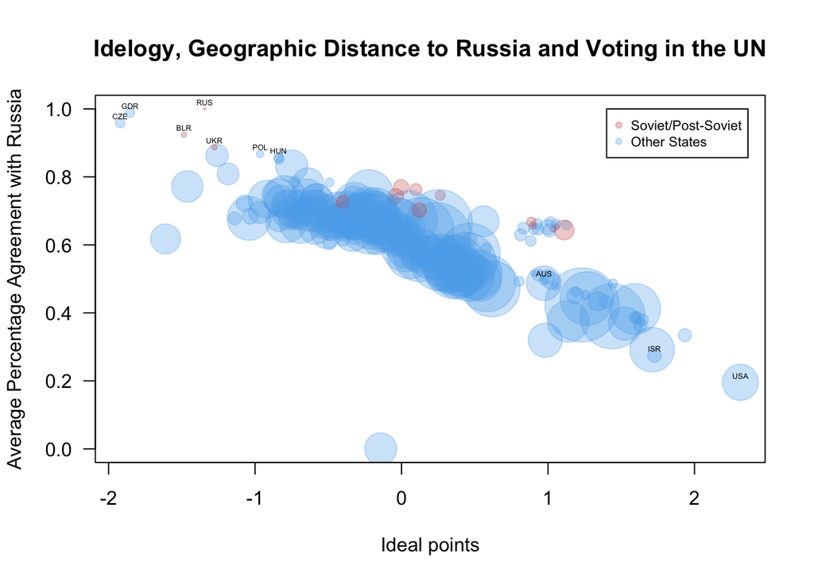

## Evaluation

- 5 questions for a total of 100 points
- 1 bonus question for 25 points